# Tadawul Future Prediction

```r
if(!require(quantmod)) install.packages("quantmod")
if(!require(forecast)) install.packages("forecast")
if(!require(tseries)) install.packages("tseries")
if(!require(timeSeries)) install.packages("timeSeries")
if(!require(dplyr)) install.packages("dplyr")
if(!require(fGarch)) install.packages("fGarch")
if(!require(prophet)) install.packages("prophet")
library(prophet)
library(quantmod)
library(forecast)
library(tseries)
library(timeSeries)
library(dplyr)
library(fGarch)
library(ggplot2)
```

## Overview:

- For this project I will start with a general idea of the market price, including dataset analysis. Followed by a general description and analysis of the dataset. The objective is to apply different forecasting predictive models for the Saudi stock market daily close price. The models will be evaluated, analysed and compared, following the main course project directions. For this evaluations I will focus in the train set accuracy performance of the models, trying to simplify our analysis due to our aim is showing new forecasting applications and encourage the open source use of them.
- This report describes different time series and machine learning forecasting models applied to a Sadui stock market (Tadawuel) close price for he past 10 years, up untill the the end of last month data. The data will be divided 70/30. I will divie into analyzing the first 7 years of the data going from 2010 - 2017, and leave the last 3 years (2017-2020) to compare the out come.

|  | ï..Date | Price | Open | High | Low | Vol. | Change.. |
| --- | --- | --- | --- | --- | --- | --- | --- |
| 1 | 13/12/2020 | 8,644.47 | 8,668.31 | 8,680.83 | 8,633.81 | 321.96M | 0.01% |
| 2 | 10/12/2020 | 8,643.97 | 8,660.21 | 8,667.98 | 8,637.23 | 338.73M | -0.19% |
| 3 | 09/12/2020 | 8,660.21 | 8,612.13 | 8,663.86 | 8,613.57 | 367.76M | 0.56% |
| 4 | 08/12/2020 | 8,612.13 | 8,633.38 | 8,636.37 | 8,584.49 | 391.85M | -0.25% |
| 5 | 07/12/2020 | 8,633.38 | 8,581.68 | 8,633.38 | 8,536.92 | 369.44M | 0.60% |
| 6 | 06/12/2020 | 8,581.68 | 8,674.97 | 8,703.33 | 8,580.92 | 376.34M | -1.08% |

## Methods:

#### Preliminary Analysis:

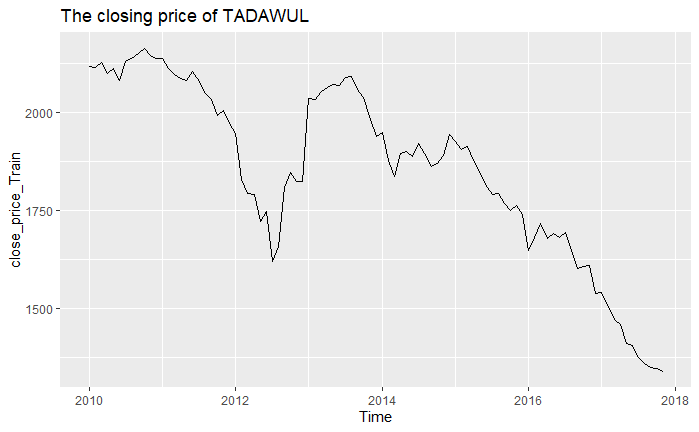

```r
autoplot(close_price_Train)+
  ggtitle("The closing price of TADAWUL")
```

```r
  ylab("Traded in Saudi Riyal")
```

```
$y
[1] "Traded in Saudi Riyal"

attr(,"class")
[1] "labels"
```

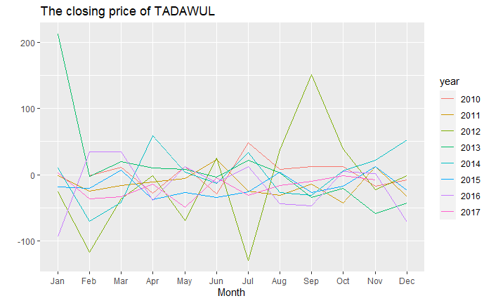

```r
DY <- diff(close_price_Train)
ggseasonplot(DY)+
  ggtitle("The closing price of TADAWUL")
```

```r
  ylab("Traded in Saudi Riyal")
```

```
$y
[1] "Traded in Saudi Riyal"

attr(,"class")
[1] "labels"
```

- The above plot shows that the data does not have seasonality

#### Arima: Autoregresive Integrating Moving Average:

```r
# Conduct ADF test for dataset
print(adf.test(close_price_Train))
```

```
    Augmented Dickey-Fuller Test

data:  close_price_Train
Dickey-Fuller = -2.4836, Lag order = 4, p-value = 0.3767
alternative hypothesis: stationary
```

- In statistics and econometrics, an augmented Dickey–Fuller test (ADF) tests the null hypothesis that a unit root is present in a time series sample.
- In general, a p-value of less than 5% means you can reject the null hypothesis that there is a unit root. You can also compare the calculated DFT statistic with a tabulated critical value. Since p-value = 0.3767 (greater than 5%) –> we cannot reject the null hypothesis)
- After the ADF test we apply the ACF and PACF functions to the dataset:

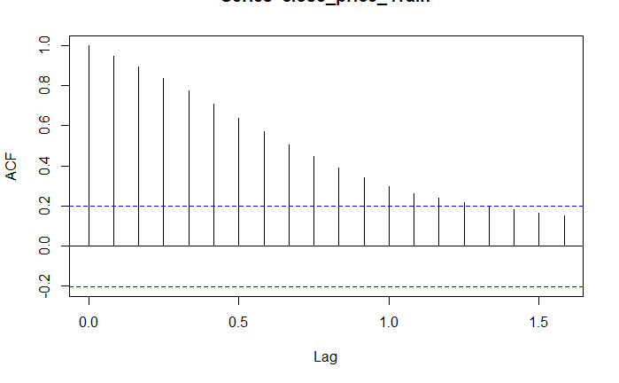

```r
acf(close_price_Train) #The correlation between the observation at the current time spot and the observations at previous time spots.
```

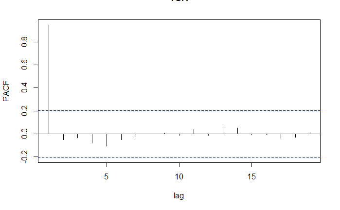

```r
pacfPlot(close_price_Train)
```

```r
#https://www.youtube.com/watch?v=Icl9_46_RZY&pbjreload=101
```

- For identifying the (p) order of the AR model we use the PACF plot. For MA models we will use ACF plot to identify the (q) order and the PACF will dampen exponentially. If we look the PACF plot, we can note that the it has a significant spike only at first lags, meaning that all the higher-order autocorrelations are effectively explained by the first lag autocorrelation.

```
    Ljung-Box test

data:  Residuals from ARIMA(0,1,0) with drift
Q* = 36.564, df = 18, p-value = 0.005971

Model df: 1.   Total lags used: 19
```

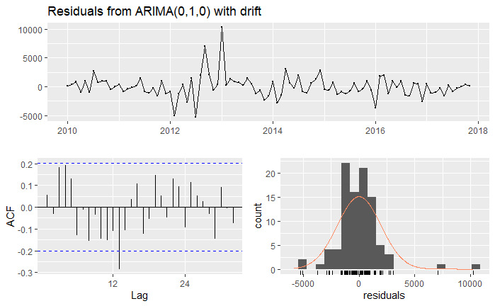

```r
#We apply auto arima to the dataset
modelfit <- auto.arima(close_price_Train, lambda = "auto")

checkresiduals(modelfit)
```

- The residuals are equal to the difference between the observations and the corresponding fitted values

*-H0: The dataset points are independently distributed.

*With this null hypothesis, a significant p-value greater than 0.05 does not rejects the fact that the dataset points are not correlated.

```r
#Box test for lag=2
Box.test(modelfit$residuals, lag= 2, type="Ljung-Box")
```

```
    Box-Ljung test

data:  modelfit$residuals
X-squared = 0.41746, df = 2, p-value = 0.8116
```

```r
#Box test for lag=2
Box.test(modelfit$residuals, type="Ljung-Box")
```

```
    Box-Ljung test

data:  modelfit$residuals
X-squared = 0.30842, df = 1, p-value = 0.5786
```

#### Arima Results:

```r
#Dataset forecasting for the next 3 years

price_forecast <- forecast(modelfit, h=36) #unit time = 1 month
accuracy(price_forecast,close_price_Test) #testing the accuracy of ARIMA
```

```
                      ME      RMSE       MAE         MPE      MAPE      MASE
Training set  -0.2472498  42.67673  28.03328 -0.07133469  1.536766 0.1552209
Test set     835.6994026 840.15941 835.69940 41.94315237 41.943152 4.6272882
                   ACF1 Theil's U
Training set 0.05089841        NA
Test set     0.86022526  16.27034
```

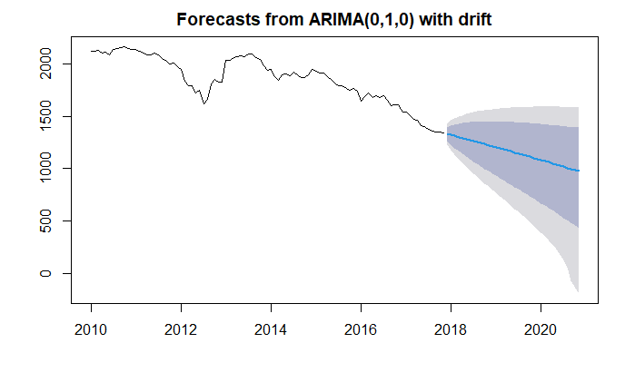

```r
#Dataset forecasting plot for the next 365 days
plot(price_forecast)
```

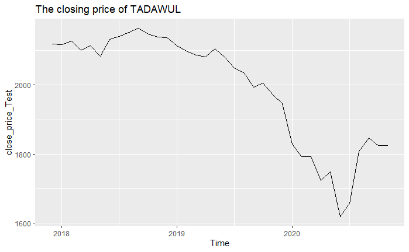

```r
autoplot(close_price_Test)+ #test the future 3 years
  ggtitle("The closing price of TADAWUL")
```

```r
  ylab("Traded in Saudi Riyal")
```

```
$y
[1] "Traded in Saudi Riyal"

attr(,"class")
[1] "labels"
```

- The darker and light darker areas, representing 80% and 95% confidence intervals respectively in lower and upper scenarios.

```r
#Dataset forecast lower first 5 values AND upper
head(price_forecast$lower)
```

```
              80%      95%
Dec 2017 1263.731 1228.166
Jan 2018 1226.121 1174.866
Feb 2018 1194.540 1130.734
Mar 2018 1165.998 1091.200
Apr 2018 1139.339 1054.493
May 2018 1113.971 1019.702
```

```r
head(price_forecast$upper)
```

```
              80%      95%
Dec 2017 1393.789 1427.182
Jan 2018 1410.799 1457.625
Feb 2018 1421.656 1478.686
Mar 2018 1429.348 1494.926
Apr 2018 1435.026 1508.105
May 2018 1439.278 1519.123
```

```r
#Dividing the data into train and test, applying the model
N = length(close_price)
n = 0.7*N
train = close_price[1:n]
test  = close_price[(n+1):N]
trainarimafit <- auto.arima(train, lambda = "auto")
predlen=length(test)
trainarimafit <- forecast(trainarimafit, h=predlen)
accuracy(trainarimafit,test)
```

```
                      ME      RMSE       MAE         MPE      MAPE      MASE
Training set  -0.4748871  43.58765  29.06514 -0.08407347  1.589543 0.9638402
Test set     146.8416145 186.84619 148.39257 11.61566674 11.736133 4.9209034
                   ACF1
Training set 0.04800713
Test set             NA
```

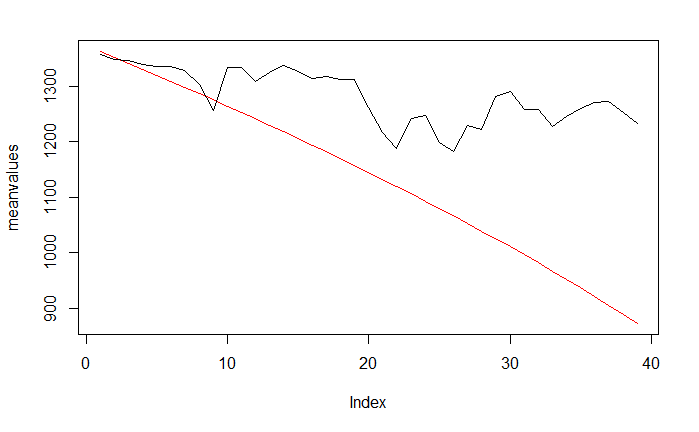

```r
#Plotting mean predicted values vs real data
meanvalues <- as.vector(trainarimafit$mean)
precios <- as.vector(test)
plot(meanvalues, type= "l", col= "red")
lines(precios, type = "l")
```

## Prophet:

- The origin of prophet comes from the application of a forecasting model into supply chain management, sales and economics. This model helps with a statistical approach in shaping business decisions.The Prophet model has been developed by Facebook’s Core Data Science team and it is an open-source tool for business forecasting.  
  *Prophet forecast flow:

$y(t)=g(t)+s(t)+h(t)+ϵ$

* The Prophet model is an additive model with the components g(t) models trends, s(t) models seasonality with Fourier series, h(t) effects of holidays or large events.

- The fist step before forecasting using prophet is to convert the dataset into the format that Prophet input requires.

```r
N = length(dates)
n = 0.3*N
proph <- data.frame(ds = dates[(n+1):N], #adding the two columns of dates and prices to a data
                 y = values[(n+1):N])
proph
```

| ds | y |
| --- | --- |
| 2017-11-28 | 6,967.35 |
| 2017-11-27 | 6,939.21 |
| 2017-11-26 | 6,933.77 |
| 2017-11-23 | 6,878.21 |
| 2017-11-22 | 6,822.45 |
| 2017-11-21 | 6,778.32 |
| 2017-11-20 | 6,804.23 |
| 2017-11-19 | 6,872.16 |
| 2017-11-16 | 6,913.46 |
| 2017-11-15 | 6,912.35 |

[output cut: 990 more lines]

```r
model1 <- prophet(proph) #Once we have converted the data we can proceed to apply the model with the dataset and predict future values.
```

```
Disabling daily seasonality. Run prophet with daily.seasonality=TRUE to override this.
```

```r
future <- make_future_dataframe(model1, periods = 365*3) # predicting a year
forecast_prophet <- predict(model1, future)
dyplot.prophet(model1,forecast_prophet)
```

[interactive chart not shown]

- With the model applied and the forecast plotted we proceed to calculate the model performance.

```r
#Creating train prediction datset to compare the real data
dataprediction <- data.frame(forecast_prophet$ds,forecast_prophet$yhat)
trainlen <- length(close_price)
dataprediction <- dataprediction[c(1:trainlen),]
#Once we have created our dataset to compare the real data against the predicted values y hat we proceed to calculate de accuracy.
```

```r
#Creating cross validation
accuracy(dataprediction$forecast_prophet.y,model1$y)
```

```
          ME RMSE MAE MPE MAPE
Test set NaN  NaN NaN NaN  NaN
```

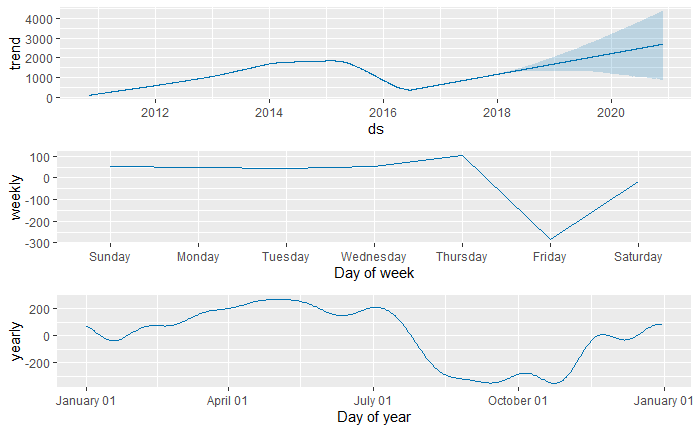

```r
#Creating cross validation
prophet_plot_components(model1,forecast_prophet)
```

## Feed Foward Neural network

- Researching deeply in new machine learning models I have reached some new neural network function in the forecast package called nneta
- A single hidden layer neural network is the most simple neural networks form. In this single hidden layer form there is only one layer of input nodes that send weighted inputs to a subsequent layer of receiving nodes. This nnetar function in the forecast package fits a single hidden layer neural network model to a timeseries. The function model approach is to use lagged values of the time series as input data, reaching to a non-linear autoregressive model.

```r
#Hidden layers creation

#With the hidden layers approach explained we proceed to calculate them:

alpha <- 1.5^(-10)
hn <- length(close_price)/(alpha*(length(close_price)+30))
```

- with the hidden layers calculated we proceed to apply the nnetar function with the parameters selected.

```r
#Fitting nnetar

#
lambda <- BoxCox.lambda(close_price)
dnn_pred <- nnetar(close_price_Train, size= hn, lambda = lambda)
```

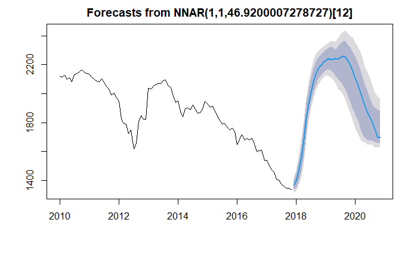

```r
#Fitting nnetar
dnn_forecast <- forecast(dnn_pred, h= 36, PI = TRUE) #forcast from 2017-2020
plot(dnn_forecast)
```

```r
accuracy(dnn_forecast,close_price_Test)
```

```
                     ME      RMSE       MAE         MPE      MAPE      MASE
Training set -0.2079346  31.45947  22.60881 -0.04438869  1.256887 0.1251855
Test set      5.5033273 287.67856 224.89920 -0.23249763 11.263484 1.2452724
                   ACF1 Theil's U
Training set -0.1550325        NA
Test set      0.8781491  4.987503
```